# FINAL_FMST_GaneshBalusait

```python
import pandas as pd
import numpy as np
import matplotlib.pyplot as plt
%matplotlib inline
import seaborn as sns

import warnings
warnings.filterwarnings('ignore')

from sklearn.ensemble import BaggingRegressor, GradientBoostingRegressor,AdaBoostRegressor
```

```python
df = pd.read_csv('concrete.csv')
```

```python
df.head()
```

|  | cement | slag | ash | water | superplastic | coarseagg | fineagg | age | strength |
| --- | --- | --- | --- | --- | --- | --- | --- | --- | --- |
| 0 | 141.3 | 212.0 | 0.0 | 203.5 | 0.0 | 971.8 | 748.5 | 28 | 29.89 |
| 1 | 168.9 | 42.2 | 124.3 | 158.3 | 10.8 | 1080.8 | 796.2 | 14 | 23.51 |
| 2 | 250.0 | 0.0 | 95.7 | 187.4 | 5.5 | 956.9 | 861.2 | 28 | 29.22 |
| 3 | 266.0 | 114.0 | 0.0 | 228.0 | 0.0 | 932.0 | 670.0 | 28 | 45.85 |
| 4 | 154.8 | 183.4 | 0.0 | 193.3 | 9.1 | 1047.4 | 696.7 | 28 | 18.29 |

```python
# Get more ifo
df.info()
```

```
<class 'pandas.core.frame.DataFrame'>
RangeIndex: 1030 entries, 0 to 1029
Data columns (total 9 columns):
 #   Column        Non-Null Count  Dtype
---  ------        --------------  -----
 0   cement        1030 non-null   float64
 1   slag          1030 non-null   float64
 2   ash           1030 non-null   float64
 3   water         1030 non-null   float64
 4   superplastic  1030 non-null   float64
 5   coarseagg     1030 non-null   float64
 6   fineagg       1030 non-null   float64
 7   age           1030 non-null   int64
 8   strength      1030 non-null   float64
dtypes: float64(8), int64(1)
memory usage: 72.5 KB
```

```python
df.describe().transpose()
```

|  | count | mean | std | min | 25% | 50% | 75% | max |
| --- | --- | --- | --- | --- | --- | --- | --- | --- |
| cement | 1030.0 | 281.167864 | 104.506364 | 102.00 | 192.375 | 272.900 | 350.000 | 540.0 |
| slag | 1030.0 | 73.895825 | 86.279342 | 0.00 | 0.000 | 22.000 | 142.950 | 359.4 |
| ash | 1030.0 | 54.188350 | 63.997004 | 0.00 | 0.000 | 0.000 | 118.300 | 200.1 |
| water | 1030.0 | 181.567282 | 21.354219 | 121.80 | 164.900 | 185.000 | 192.000 | 247.0 |
| superplastic | 1030.0 | 6.204660 | 5.973841 | 0.00 | 0.000 | 6.400 | 10.200 | 32.2 |
| coarseagg | 1030.0 | 972.918932 | 77.753954 | 801.00 | 932.000 | 968.000 | 1029.400 | 1145.0 |
| fineagg | 1030.0 | 773.580485 | 80.175980 | 594.00 | 730.950 | 779.500 | 824.000 | 992.6 |
| age | 1030.0 | 45.662136 | 63.169912 | 1.00 | 7.000 | 28.000 | 56.000 | 365.0 |
| strength | 1030.0 | 35.817961 | 16.705742 | 2.33 | 23.710 | 34.445 | 46.135 | 82.6 |

```python
# Get the shape and size of the dataset
df.shape
```

```
(1030, 9)
```

```python
# check any missing value
df.isnull().any().sum()
```

```
0
```

```python
df[~df.applymap(np.isreal)].sum()
```

```
cement          0.0
slag            0.0
ash             0.0
water           0.0
superplastic    0.0
coarseagg       0.0
fineagg         0.0
age             0.0
strength        0.0
dtype: float64
```

### Univariate Analysis

###### BOX Plot

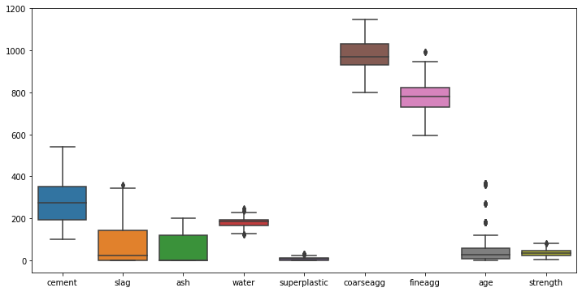

```python
plt.figure(figsize=(12,6))
sns.boxplot(data=df)
```

```python
df.columns
```

```
Index(['cement', 'slag', 'ash', 'water', 'superplastic', 'coarseagg',
       'fineagg', 'age', 'strength'],
      dtype='object')
```

```
cement 0
slag 1
ash 2
water 3
superplastic 4
coarseagg 5
fineagg 6
age 7
```

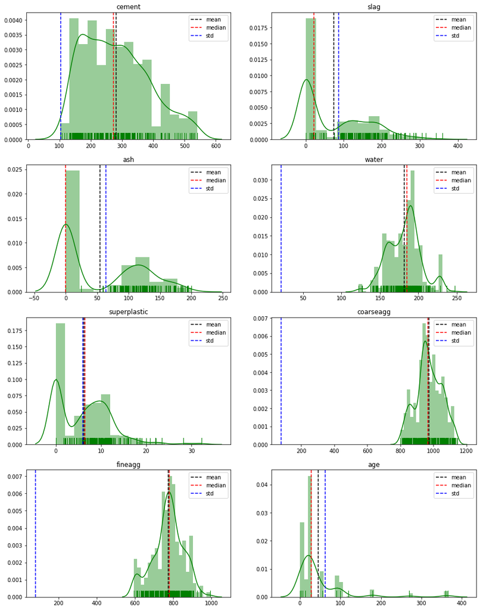

```python
import itertools
plt.figure(figsize=(15,20))

col=['cement', 'slag', 'ash', 'water', 'superplastic', 'coarseagg',
       'fineagg', 'age']
for i,j in itertools.zip_longest(col,range(len(col))):
    print(i,j)
    plt.subplot(4,2,j+1)
    ax = sns.distplot(df[i],color='green',rug=True)
    plt.axvline(df[i].mean(),linestyle="dashed",label="mean", color='black')
    plt.axvline(df[i].median(),linestyle="dashed",label="median", color='red')
    plt.axvline(df[i].std(),linestyle="dashed",label="std", color='blue')
    plt.legend()
    plt.title(i)
    plt.xlabel("")
```

##### - Target feature

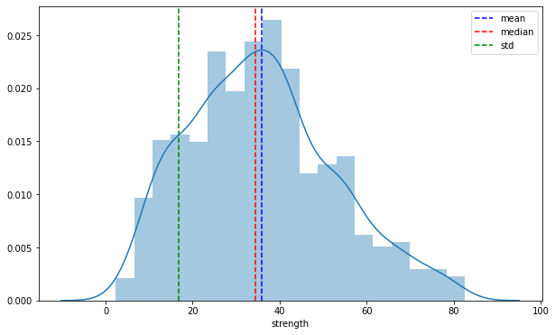

```python
plt.figure(figsize=(10,6))
plt.axvline(df.strength.mean(),linestyle='dashed',label='mean',color='blue')
plt.axvline(df.strength.median(),linestyle='dashed',label='median',color='red')
plt.axvline(df.strength.std(),linestyle='dashed',label='std',color='green')

plt.legend()
sns.distplot(df.strength)
```

```python
(df==0).sum()
```

```
cement            0
slag            471
ash             566
water             0
superplastic    379
coarseagg         0
fineagg           0
age               0
strength          0
dtype: int64
```

- No need to treatment 0s for null value

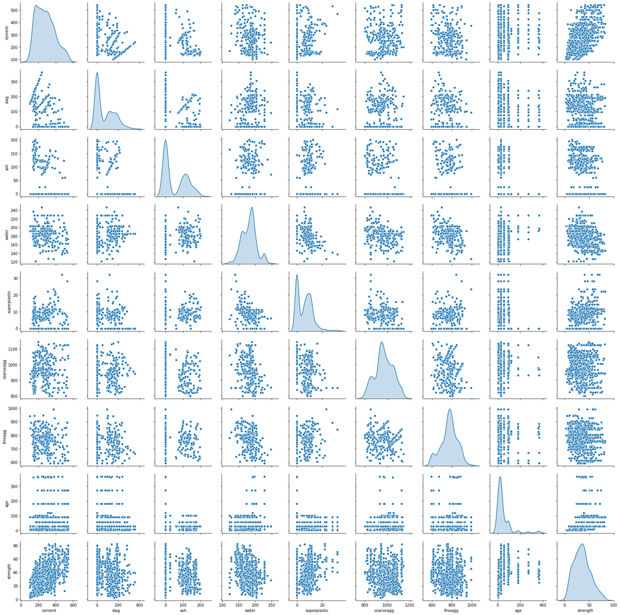

```python
sns.pairplot(df, diag_kind='kde')
```

```python
df.head()
```

|  | cement | slag | ash | water | superplastic | coarseagg | fineagg | age | strength |
| --- | --- | --- | --- | --- | --- | --- | --- | --- | --- |
| 0 | 141.3 | 212.0 | 0.0 | 203.5 | 0.0 | 971.8 | 748.5 | 28 | 29.89 |
| 1 | 168.9 | 42.2 | 124.3 | 158.3 | 10.8 | 1080.8 | 796.2 | 14 | 23.51 |
| 2 | 250.0 | 0.0 | 95.7 | 187.4 | 5.5 | 956.9 | 861.2 | 28 | 29.22 |
| 3 | 266.0 | 114.0 | 0.0 | 228.0 | 0.0 | 932.0 | 670.0 | 28 | 45.85 |
| 4 | 154.8 | 183.4 | 0.0 | 193.3 | 9.1 | 1047.4 | 696.7 | 28 | 18.29 |

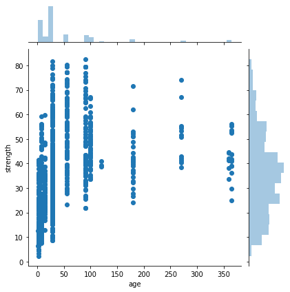

```python
sns.jointplot(data=df, x='age', y='strength')
```

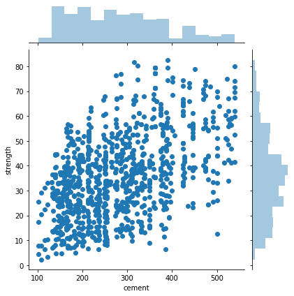

```python
plt.figure(figsize=(15,6))

sns.jointplot(data=df, x='cement', y='strength')
```

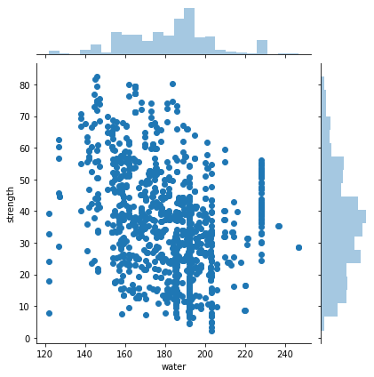

```python
plt.figure(figsize=(15,6))

sns.jointplot(data=df, x='water', y='strength')
```

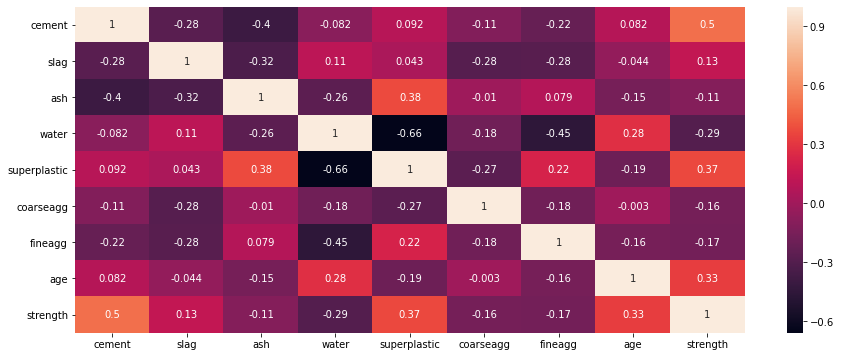

```python
plt.figure(figsize=(15,6))
sns.heatmap(df.corr(),annot=True)
```

#### Feature Engineering and Model Building

```python
df.head()
```

|  | cement | slag | ash | water | superplastic | coarseagg | fineagg | age | strength |
| --- | --- | --- | --- | --- | --- | --- | --- | --- | --- |
| 0 | 141.3 | 212.0 | 0.0 | 203.5 | 0.0 | 971.8 | 748.5 | 28 | 29.89 |
| 1 | 168.9 | 42.2 | 124.3 | 158.3 | 10.8 | 1080.8 | 796.2 | 14 | 23.51 |
| 2 | 250.0 | 0.0 | 95.7 | 187.4 | 5.5 | 956.9 | 861.2 | 28 | 29.22 |
| 3 | 266.0 | 114.0 | 0.0 | 228.0 | 0.0 | 932.0 | 670.0 | 28 | 45.85 |
| 4 | 154.8 | 183.4 | 0.0 | 193.3 | 9.1 | 1047.4 | 696.7 | 28 | 18.29 |

```python
from scipy.stats import zscore

df=df.apply(zscore)
df.head()
```

|  | cement | slag | ash | water | superplastic | coarseagg | fineagg | age | strength |
| --- | --- | --- | --- | --- | --- | --- | --- | --- | --- |
| 0 | -1.339017 | 1.601441 | -0.847144 | 1.027590 | -1.039143 | -0.014398 | -0.312970 | -0.279733 | -0.355018 |
| 1 | -1.074790 | -0.367541 | 1.096078 | -1.090116 | 0.769617 | 1.388141 | 0.282260 | -0.501465 | -0.737108 |
| 2 | -0.298384 | -0.856888 | 0.648965 | 0.273274 | -0.118015 | -0.206121 | 1.093371 | -0.279733 | -0.395144 |
| 3 | -0.145209 | 0.465044 | -0.847144 | 2.175461 | -1.039143 | -0.526517 | -1.292542 | -0.279733 | 0.600806 |
| 4 | -1.209776 | 1.269798 | -0.847144 | 0.549700 | 0.484905 | 0.958372 | -0.959363 | -0.279733 | -1.049727 |

##### Observation

using Z-scale to convert them into a single scale.

```python
df.describe()
```

|  | cement | slag | ash | water | superplastic | coarseagg | fineagg | age | strength |
| --- | --- | --- | --- | --- | --- | --- | --- | --- | --- |
| count | 1.030000e+03 | 1.030000e+03 | 1.030000e+03 | 1.030000e+03 | 1.030000e+03 | 1.030000e+03 | 1.030000e+03 | 1.030000e+03 | 1.030000e+03 |
| mean | -3.858833e-16 | 9.593189e-18 | 3.634633e-16 | -2.014570e-16 | 1.103756e-16 | 7.116206e-16 | 9.537139e-16 | 3.794160e-17 | -3.729487e-17 |
| std | 1.000486e+00 | 1.000486e+00 | 1.000486e+00 | 1.000486e+00 | 1.000486e+00 | 1.000486e+00 | 1.000486e+00 | 1.000486e+00 | 1.000486e+00 |
| min | -1.715253e+00 | -8.568879e-01 | -8.471439e-01 | -2.800211e+00 | -1.039143e+00 | -2.212138e+00 | -2.240917e+00 | -7.073594e-01 | -2.005552e+00 |
| 25% | -8.500535e-01 | -8.568879e-01 | -8.471439e-01 | -7.808939e-01 | -1.039143e+00 | -5.265174e-01 | -5.319697e-01 | -6.123314e-01 | -7.251305e-01 |
| 50% | -7.915193e-02 | -6.017783e-01 | -8.471439e-01 | 1.608294e-01 | 3.271508e-02 | -6.329352e-02 | 7.386739e-02 | -2.797331e-01 | -8.222491e-02 |
| 75% | 6.589606e-01 | 8.007446e-01 | 1.002278e+00 | 4.887927e-01 | 6.691307e-01 | 7.267605e-01 | 6.291661e-01 | 1.637312e-01 | 6.178744e-01 |
| max | 2.477915e+00 | 3.310675e+00 | 2.281084e+00 | 3.065647e+00 | 4.353642e+00 | 2.214224e+00 | 2.733062e+00 | 5.057677e+00 | 2.801717e+00 |

```python
X=df.drop('strength',axis=1)
y=df['strength']
```

##### Split Train and test data

```python
from sklearn.model_selection import train_test_split

X_train, X_test, y_train, y_test = train_test_split(X, y, test_size=0.3, random_state=1)
```

```python
from sklearn.ensemble import RandomForestRegressor

rf= RandomForestRegressor(n_estimators=100, random_state=42)
rf.fit(X_train, y_train)
```

```
RandomForestRegressor(bootstrap=True, criterion='mse', max_depth=None,
           max_features='auto', max_leaf_nodes=None,
           min_impurity_decrease=0.0, min_impurity_split=None,
           min_samples_leaf=1, min_samples_split=2,
           min_weight_fraction_leaf=0.0, n_estimators=100, n_jobs=None,
           oob_score=False, random_state=42, verbose=0, warm_start=False)
```

```python
y_predit = rf.predict(X_test)
```

```python
from sklearn.metrics import accuracy_score,mean_squared_error,mean_absolute_error,r2_score
```

```python
print('Training Score',rf.score(X_train, y_train))

print('Testing Score',rf.score(X_test, y_test))
```

```
Training Score 0.9822810948591015
Testing Score 0.8998428068592238
```

```python
rf.feature_importances_
```

```
array([0.31805257, 0.07178892, 0.02217521, 0.11146393, 0.05883468,
       0.0276554 , 0.03943773, 0.35059155])
```

```python
df.shape
```

```
(1030, 9)
```

##### finding out the feature selection from the dataset

```python
dset = pd.DataFrame()
dset['attr'] = X.columns
dset['importance'] = rf.feature_importances_
dset = dset.sort_values(by='importance',ascending=False)
```

```python
dset
```

|  | attr | importance |
| --- | --- | --- |
| 7 | age | 0.350592 |
| 0 | cement | 0.318053 |
| 3 | water | 0.111464 |
| 1 | slag | 0.071789 |
| 4 | superplastic | 0.058835 |
| 6 | fineagg | 0.039438 |
| 5 | coarseagg | 0.027655 |
| 2 | ash | 0.022175 |

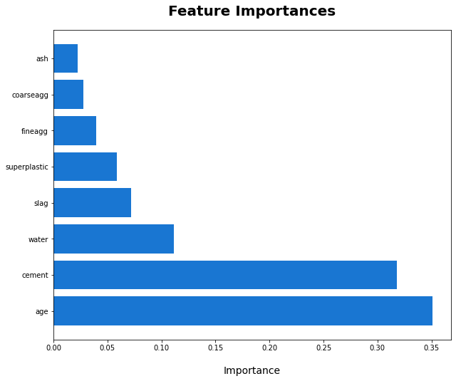

```python
plt.figure(figsize=(10, 8))
plt.barh(y=dset['attr'], width=dset['importance'], color='#1976D2')
plt.title('Feature Importances', fontsize=20, fontweight='bold', pad=20)
plt.xlabel('Importance', fontsize=14, labelpad=20)
plt.show()
```

```python
from sklearn.model_selection import StratifiedKFold
from sklearn.feature_selection import RFE

rfc = RandomForestRegressor(random_state=101)
rfecv = RFE(estimator=rfc, step = 1)

rfecv.fit(X_train,y_train)
```

```
RFE(estimator=RandomForestRegressor(bootstrap=True, criterion='mse', max_depth=None,
           max_features='auto', max_leaf_nodes=None,
           min_impurity_decrease=0.0, min_impurity_split=None,
           min_samples_leaf=1, min_samples_split=2,
           min_weight_fraction_leaf=0.0, n_estimators='warn', n_jobs=None,
           oob_score=False, random_state=101, verbose=0, warm_start=False),
  n_features_to_select=None, step=1, verbose=0)
```

```python
rfecv.n_features_
```

```
4
```

```python
X.columns[np.where(rfecv.support_==False)]
```

```
Index(['ash', 'superplastic', 'coarseagg', 'fineagg'], dtype='object')
```

##### Observation

- Remove less feature column and it wont effect the model, so removing 4 columns from the dataset

```python
selective_col=X.columns[np.where(rfecv.support_==True)]
selective_col
```

```
Index(['cement', 'slag', 'water', 'age'], dtype='object')
```

#### Observation

- selecting best feature column from the dataset

##### Models to use the dataset:

- Linear Regression
- PolyNomial Feature - 2
- PolyNomial Feature - 3
- Ridge
- Lasso
- Decision Tree Regressor

##### Enasemble Technique:

- RandomForest Regressor
- Bagging Regressor
- AdaBoosting Regressor
- Gradient Boosting Regressor

```python
from sklearn.linear_model import LinearRegression, Ridge, Lasso
from sklearn.preprocessing import PolynomialFeatures
from sklearn.pipeline import Pipeline
from sklearn.tree import DecisionTreeRegressor
from sklearn.metrics import r2_score
```

```python
# assigining best column and feed into the data
X_train=X_train[['cement', 'slag', 'water', 'age']]
X_train
```

|  | cement | slag | water | age |
| --- | --- | --- | --- | --- |
| 185 | 0.658961 | -0.856888 | 1.004164 | -0.501465 |
| 286 | 0.888723 | 1.337055 | -0.537264 | 0.718062 |
| 600 | -0.039901 | -0.856888 | 0.441941 | -0.675683 |
| 691 | 0.946164 | 0.244722 | 2.175461 | -0.612331 |
| 474 | 0.716401 | -0.856888 | 0.535645 | -0.279733 |
| ... | ... | ... | ... | ... |
| 960 | -0.281152 | -0.856888 | -1.661710 | -0.675683 |
| 847 | -1.112126 | -0.856888 | -0.832431 | -0.675683 |
| 715 | 0.214753 | 0.765377 | 1.496109 | -0.279733 |
| 905 | 0.352610 | -0.856888 | 1.332127 | -0.279733 |
| 235 | -0.432412 | -0.856888 | 0.582497 | -0.675683 |

721 rows × 4 columns

```python
X_test=X_test[['cement', 'slag', 'water', 'age']]
X_test
```

|  | cement | slag | water | age |
| --- | --- | --- | --- | --- |
| 339 | -0.432412 | 0.963667 | 0.488793 | 0.702224 |
| 244 | 1.070619 | -0.856888 | 0.488793 | 0.702224 |
| 882 | -0.647814 | -0.856888 | -1.263468 | -0.501465 |
| 567 | -1.207861 | 1.265160 | 0.535645 | -0.279733 |
| 923 | 0.276023 | -0.856888 | 0.488793 | -0.612331 |
| ... | ... | ... | ... | ... |
| 1018 | -1.284448 | 0.476640 | 0.957312 | -0.279733 |
| 1015 | 0.161142 | -0.856888 | 0.207681 | -0.279733 |
| 341 | -0.955122 | -0.856888 | -0.560690 | 0.860604 |
| 750 | 0.496212 | -0.653960 | -0.682505 | -0.279733 |
| 937 | 0.706828 | -0.636566 | -1.713247 | -0.279733 |

309 rows × 4 columns

```python
y_train
```

```
185   -0.795799
286    1.741687
600   -1.464756
691   -0.179544
474    0.302560
         ...
960   -0.886231
847   -1.282695
715   -0.143611
905    0.254050
235   -1.757612
Name: strength, Length: 721, dtype: float64
```

```python
from sklearn.model_selection import KFold,cross_val_score

kfold= KFold(n_splits=10, random_state=7)
```

#### LinearRegression

```python
lineaR=LinearRegression()

lineaR.fit(X_train, y_train)

print('Coefficent:',lineaR.coef_)

trainingScore=lineaR.score(X_train,y_train)
testingScore=lineaR.score(X_test,y_test)
y_predicted = lineaR.predict(X_test)

#print('Training Score',trainingScore)

RMSE=np.sqrt(mean_squared_error(y_test,y_predicted))
MSE = mean_squared_error(y_test, y_predicted)
MAE = mean_absolute_error(y_test, y_predicted)
R2Score = r2_score(y_test, y_predicted)
Linear_CV=cross_val_score(lineaR, X_test, y_test, cv=kfold,scoring='neg_mean_squared_error').ravel()


# modeling.append('Linear Regression')
# scores.append(linear_score)
# TRS.append(trainingScore)

MLA=lineaR.__class__.__name__

#compare_model = pd.DataFrame({'Model': 'Linear','scores': scores,'Training Score': TRS})
linear_model=pd.DataFrame([[MLA, trainingScore,testingScore,RMSE,MSE,MAE,R2Score, Linear_CV.mean(),Linear_CV.std(),Linear_CV.min(),Linear_CV.max()]],
                          columns=['Model','Training Score','Testing Score','RMSE','MSE','MAE','R2Score','CV_Mean','CV_std','CV_min','CV_max'])
#    return pd.DataFrame([[MLA, trainR2Score, testR2Score]],columns=['MLA','trainR2Score','testR2Score'])
linear_model
```

```
Coefficent: [ 0.52895478  0.32118484 -0.38584614  0.3870876 ]
```

|  | Model | Training Score | Testing Score | RMSE | MSE | MAE | R2Score | CV_Mean | CV_std | CV_min | CV_max |
| --- | --- | --- | --- | --- | --- | --- | --- | --- | --- | --- | --- |
| 0 | LinearRegression | 0.548984 | 0.574067 | 0.666794 | 0.444615 | 0.545648 | 0.574067 | -0.452963 | 0.106043 | -0.685468 | -0.312445 |

```python
from matplotlib.pyplot import subplots, show
```

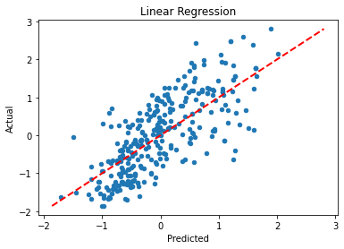

```python
fig, ax = subplots()

ax.scatter(y_predicted, y_test,s=20,)
ax.plot([y_test.min(),y_test.max()],[y_test.min(),y_test.max()],'k--',lw=2,color='red')
plt.title('Linear Regression')

ax.set_xlabel('Predicted')
ax.set_ylabel("Actual")
plt.show()
```

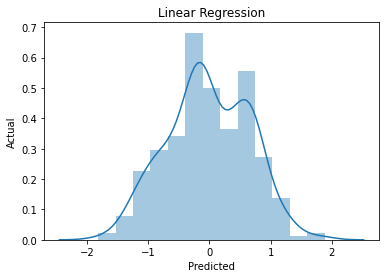

```python
fig, ax = subplots()


sns.distplot(y_predicted - y_test)
plt.title('Linear Regression')
ax.set_xlabel('Predicted')
ax.set_ylabel("Actual")
plt.show()
```

##### Observations

- plotting distplot & scatter plot, verifing the model is best fit for this dataset.

##### PolyNomial Regression - Degree 2:

```python
poly2=PolynomialFeatures(degree=2, interaction_only=True)

X_polytrain2=poly2.fit_transform(X_train)
X_polytest2=poly2.fit_transform(X_test)

print('X_polytrain2',X_polytrain2.shape)

lineaR.fit(X_polytrain2, y_train)

trainingScore=lineaR.score(X_polytrain2,y_train)
testingScore=lineaR.score(X_polytest2,y_test)
y_predicted2 = lineaR.predict(X_polytest2)

#print('Training Score',trainingScore)

RMSE=np.sqrt(mean_squared_error(y_test,y_predicted2))
MSE = mean_squared_error(y_test, y_predicted2)
MAE = mean_absolute_error(y_test, y_predicted2)
R2Score = r2_score(y_test, y_predicted2)
poly2_CV=cross_val_score(lineaR, X_polytrain2, y_train.values.ravel(), cv=kfold,scoring='neg_mean_squared_error').mean()



Poly2Model=pd.DataFrame([['PolyNomialDegree2', trainingScore,testingScore,RMSE,MSE,MAE,R2Score, poly2_CV.mean(),poly2_CV.std(),poly2_CV.min(),poly2_CV.max()]],
                          columns=['Model','Training Score','Testing Score','RMSE','MSE','MAE','R2Score','CV_Mean','CV_std','CV_min','CV_max'])
Poly2Model
```

```
X_polytrain2 (721, 11)
```

|  | Model | Training Score | Testing Score | RMSE | MSE | MAE | R2Score | CV_Mean | CV_std | CV_min | CV_max |
| --- | --- | --- | --- | --- | --- | --- | --- | --- | --- | --- | --- |
| 0 | PolyNomialDegree2 | 0.610062 | 0.623311 | 0.627065 | 0.393211 | 0.510559 | 0.623311 | -0.412956 | 0.0 | -0.412956 | -0.412956 |

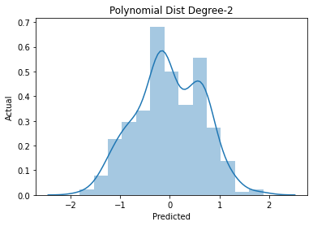

```python
fig, ax = subplots()

#ax.scatter(y_predicted, y_test,s=20,)
#sns.relplot(X='y_predicted',y='y_test',kind='line',data=ds)
sns.distplot(y_predicted - y_test)
#ax.plot([y_test.min(),y_test.max()],[y_test.min(),y_test.max()],'k--',lw=2,color='red')
plt.title('Polynomial Dist Degree-2')

ax.set_xlabel('Predicted')
ax.set_ylabel("Actual")
#plt.xlabel('Predicted')
#plt.ylabel('Actual')
plt.show()
```

##### Observations

- plotting distplot, verifing the model is best fit for this dataset.

##### PolyNomial Regression - Degree 3:

```python
poly3=PolynomialFeatures(degree=3, interaction_only=True)

X_polytrain3=poly3.fit_transform(X_train)
X_polytest3=poly3.fit_transform(X_test)

print('X_polytrain3',X_polytrain2.shape)

lineaR.fit(X_polytrain3, y_train)

trainingScore=lineaR.score(X_polytrain3,y_train)
testingScore=lineaR.score(X_polytest3,y_test)
y_predicted3 = lineaR.predict(X_polytest3)

#print('Training Score',trainingScore)

RMSE=np.sqrt(mean_squared_error(y_test,y_predicted3))
MSE = mean_squared_error(y_test, y_predicted3)
MAE = mean_absolute_error(y_test, y_predicted3)
R2Score = r2_score(y_test, y_predicted3)
poly3_CV=cross_val_score(lineaR, X_polytrain3, y_train.values.ravel(), cv=kfold,scoring='neg_mean_squared_error').mean()


Poly3Model=pd.DataFrame([['PolyNomialDegree3', trainingScore,testingScore,RMSE,MSE,MAE,R2Score, poly3_CV.mean(),poly3_CV.std(),poly3_CV.min(),poly3_CV.max()]],
                          columns=['Model','Training Score','Testing Score','RMSE','MSE','MAE','R2Score','CV_Mean','CV_std','CV_min','CV_max'])

Poly3Model
```

```
X_polytrain3 (721, 11)
```

|  | Model | Training Score | Testing Score | RMSE | MSE | MAE | R2Score | CV_Mean | CV_std | CV_min | CV_max |
| --- | --- | --- | --- | --- | --- | --- | --- | --- | --- | --- | --- |
| 0 | PolyNomialDegree3 | 0.618527 | 0.633315 | 0.618683 | 0.382768 | 0.502633 | 0.633315 | -0.427975 | 0.0 | -0.427975 | -0.427975 |

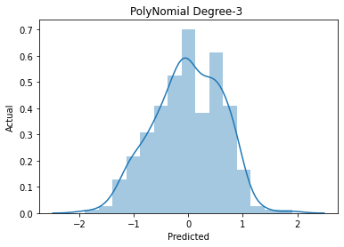

```python
fig, ax = subplots()


sns.distplot(y_predicted3 - y_test)
plt.title('PolyNomial Degree-3 ')

ax.set_xlabel('Predicted')
ax.set_ylabel("Actual")
plt.show()
```

##### Observations

- plotting distplot, verifing the model is best fit for this dataset.

#### Ridge

```python
Ridge=Ridge(alpha=0.3)

Ridge.fit(X_train, y_train)

print('Coefficent:',Ridge.coef_)

trainingScore=Ridge.score(X_train,y_train)
testingScore=Ridge.score(X_test,y_test)
y_predictedRidge = Ridge.predict(X_test)

#print('Training Score',trainingScore)

RMSE=np.sqrt(mean_squared_error(y_test,y_predictedRidge))
MSE = mean_squared_error(y_test, y_predictedRidge)
MAE = mean_absolute_error(y_test, y_predictedRidge)
R2Score = r2_score(y_test, y_predictedRidge)
Ridge_CV=cross_val_score(Ridge, X_test, y_test, cv=kfold,scoring='neg_mean_squared_error').ravel()


# modeling.append('Linear Regression')
# scores.append(linear_score)
# TRS.append(trainingScore)

MLA=Ridge.__class__.__name__

#compare_model = pd.DataFrame({'Model': 'Linear','scores': scores,'Training Score': TRS})
Ridge_model=pd.DataFrame([[MLA, trainingScore,testingScore,RMSE,MSE,MAE,R2Score, Ridge_CV.mean(),Ridge_CV.std(),Ridge_CV.min(),Ridge_CV.max()]],
                          columns=['Model','Training Score','Testing Score','RMSE','MSE','MAE','R2Score','CV_Mean','CV_std','CV_min','CV_max'])
#    return pd.DataFrame([[MLA, trainR2Score, testR2Score]],columns=['MLA','trainR2Score','testR2Score'])
Ridge_model
```

```
Coefficent: [ 0.52870903  0.3209547  -0.38561783  0.38687738]
```

|  | Model | Training Score | Testing Score | RMSE | MSE | MAE | R2Score | CV_Mean | CV_std | CV_min | CV_max |
| --- | --- | --- | --- | --- | --- | --- | --- | --- | --- | --- | --- |
| 0 | Ridge | 0.548984 | 0.57402 | 0.666831 | 0.444664 | 0.5457 | 0.57402 | -0.452929 | 0.106177 | -0.686078 | -0.31211 |

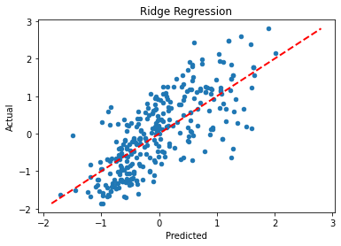

```python
from matplotlib.pyplot import subplots, show
fig, ax = subplots()

ax.scatter(y_predictedRidge, y_test,s=20)
ax.plot([y_test.min(),y_test.max()],[y_test.min(),y_test.max()],'k--',lw=2,color='red')
plt.title('Ridge Regression')

ax.set_xlabel('Predicted')
ax.set_ylabel("Actual")
plt.show()
```

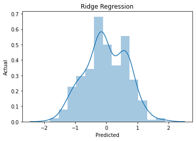

```python
fig, ax = subplots()


sns.distplot(y_predictedRidge - y_test)
plt.title('Ridge Regression')

ax.set_xlabel('Predicted')
ax.set_ylabel("Actual")
plt.show()
```

##### Observations

- plotting distplot & scatter plot, verifing the model is best fit for this dataset.

#### Lasso

```python
Lasso=Lasso(alpha=0.3)

Lasso.fit(X_train, y_train)

print('Coefficent:',Lasso.coef_)

trainingScore=Lasso.score(X_train,y_train)
testingScore=Lasso.score(X_test,y_test)
y_predictedLasso = Lasso.predict(X_test)


RMSE=np.sqrt(mean_squared_error(y_test,y_predictedLasso))
MSE = mean_squared_error(y_test, y_predictedLasso)
MAE = mean_absolute_error(y_test, y_predictedLasso)
R2Score = r2_score(y_test, y_predictedLasso)
Lasso_CV=cross_val_score(Lasso, X_test, y_test, cv=kfold,scoring='neg_mean_squared_error').ravel()


MLA=Lasso.__class__.__name__

Lasso_model=pd.DataFrame([[MLA, trainingScore,testingScore,RMSE,MSE,MAE,R2Score, Lasso_CV.mean(),Lasso_CV.std(),Lasso_CV.min(),Lasso_CV.max()]],
                          columns=['Model','Training Score','Testing Score','RMSE','MSE','MAE','R2Score','CV_Mean','CV_std','CV_min','CV_max'])
Lasso_model
```

```
Coefficent: [ 0.20584124  0.         -0.          0.        ]
```

|  | Model | Training Score | Testing Score | RMSE | MSE | MAE | R2Score | CV_Mean | CV_std | CV_min | CV_max |
| --- | --- | --- | --- | --- | --- | --- | --- | --- | --- | --- | --- |
| 0 | Lasso | 0.169588 | 0.147109 | 0.943557 | 0.890299 | 0.785277 | 0.147109 | -0.887014 | 0.272762 | -1.39553 | -0.570083 |

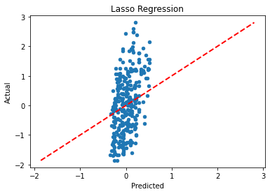

```python
fig, ax = subplots()

ax.scatter(y_predictedLasso, y_test,s=20)
ax.plot([y_test.min(),y_test.max()],[y_test.min(),y_test.max()],'k--',lw=2,color='red')
plt.title('Lasso Regression')

ax.set_xlabel('Predicted')
ax.set_ylabel("Actual")
plt.show()
```

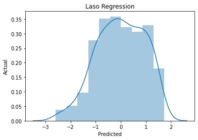

```python
fig, ax = subplots()


sns.distplot(y_predictedLasso - y_test)
plt.title('Laso Regression')

ax.set_xlabel('Predicted')
ax.set_ylabel("Actual")
plt.show()
```

##### Observation

- The mode is non linear, thus we procced to other non-linear models.

#### Decision Tree

```python
dtree=DecisionTreeRegressor()

dtree.fit(X_train, y_train)

trainingScore=dtree.score(X_train,y_train)
testingScore=dtree.score(X_test,y_test)
y_predictDtree = dtree.predict(X_test)


RMSE=np.sqrt(mean_squared_error(y_test,y_predictDtree))
MSE = mean_squared_error(y_test, y_predictDtree)
MAE = mean_absolute_error(y_test, y_predictDtree)
R2Score = r2_score(y_test, y_predictDtree)
dtree_CV=cross_val_score(dtree, X_test, y_test, cv=kfold,scoring='neg_mean_squared_error').ravel()


MLA=dtree.__class__.__name__

dtree_model=pd.DataFrame([[MLA, trainingScore,testingScore,RMSE,MSE,MAE,R2Score, dtree_CV.mean(),dtree_CV.std(),dtree_CV.min(),dtree_CV.max()]],
                          columns=['Model','Training Score','Testing Score','RMSE','MSE','MAE','R2Score','CV_Mean','CV_std','CV_min','CV_max'])

dtree_model
```

|  | Model | Training Score | Testing Score | RMSE | MSE | MAE | R2Score | CV_Mean | CV_std | CV_min | CV_max |
| --- | --- | --- | --- | --- | --- | --- | --- | --- | --- | --- | --- |
| 0 | DecisionTreeRegressor | 0.993459 | 0.843171 | 0.404608 | 0.163708 | 0.278783 | 0.843171 | -0.301554 | 0.063994 | -0.427153 | -0.174923 |

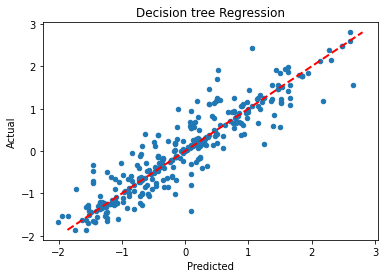

```python
fig, ax = subplots()

ax.scatter(y_predictDtree, y_test,s=20)
ax.plot([y_test.min(),y_test.max()],[y_test.min(),y_test.max()],'k--',lw=2,color='red')
plt.title('Decision tree Regression')

ax.set_xlabel('Predicted')
ax.set_ylabel("Actual")
plt.show()
```

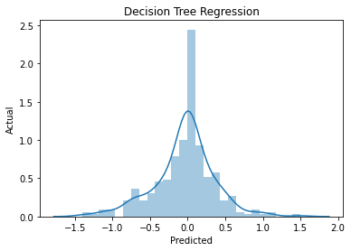

```python
fig, ax = subplots()


sns.distplot(y_predictDtree - y_test)
plt.title('Decision Tree Regression')

ax.set_xlabel('Predicted')
ax.set_ylabel("Actual")
plt.show()
```

##### Observations

- plotting distplot & scatter plot, verifing the model is best fit for this dataset.

#### Random Forest Regressor

```python
rfr=RandomForestRegressor()

rfr.fit(X_train, y_train)

trainingScore=rfr.score(X_train,y_train)
testingScore=rfr.score(X_test,y_test)
y_predictrfr = rfr.predict(X_test)


RMSE=np.sqrt(mean_squared_error(y_test,y_predictrfr))
MSE = mean_squared_error(y_test, y_predictrfr)
MAE = mean_absolute_error(y_test, y_predictrfr)
R2Score = r2_score(y_test, y_predictrfr)
rfr_CV=cross_val_score(dtree, X_test, y_test, cv=kfold,scoring='neg_mean_squared_error').ravel()


MLA=rfr.__class__.__name__

rfr_model=pd.DataFrame([[MLA, trainingScore,testingScore,RMSE,MSE,MAE,R2Score, rfr_CV.mean(),rfr_CV.std(),rfr_CV.min(),rfr_CV.max()]],
                          columns=['Model','Training Score','Testing Score','RMSE','MSE','MAE','R2Score','CV_Mean','CV_std','CV_min','CV_max'])

rfr_model
```

|  | Model | Training Score | Testing Score | RMSE | MSE | MAE | R2Score | CV_Mean | CV_std | CV_min | CV_max |
| --- | --- | --- | --- | --- | --- | --- | --- | --- | --- | --- | --- |
| 0 | RandomForestRegressor | 0.975605 | 0.877422 | 0.357707 | 0.127954 | 0.257744 | 0.877422 | -0.306362 | 0.060104 | -0.411505 | -0.177672 |

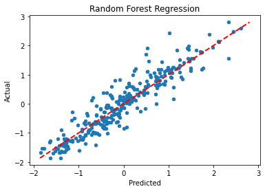

```python
fig, ax = subplots()

ax.scatter(y_predictrfr, y_test,s=20)
ax.plot([y_test.min(),y_test.max()],[y_test.min(),y_test.max()],'k--',lw=2,color='red')
plt.title('Random Forest Regression')

ax.set_xlabel('Predicted')
ax.set_ylabel("Actual")
plt.show()
```

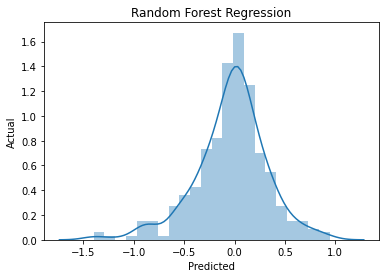

```python
fig, ax = subplots()


sns.distplot(y_predictrfr - y_test)
plt.title('Random Forest Regression')

ax.set_xlabel('Predicted')
ax.set_ylabel("Actual")
plt.show()
```

##### Observations

- To use Random Forest model and to find out the level of metrics.

#### Bagging Regressor

```python
br=BaggingRegressor()

br.fit(X_train, y_train)

trainingScore=br.score(X_train,y_train)
testingScore=br.score(X_test,y_test)
y_predictbr = br.predict(X_test)


RMSE=np.sqrt(mean_squared_error(y_test,y_predictbr))
MSE = mean_squared_error(y_test, y_predictbr)
MAE = mean_absolute_error(y_test, y_predictbr)
R2Score = r2_score(y_test, y_predictbr)
br_CV=cross_val_score(br, X_test, y_test, cv=kfold,scoring='neg_mean_squared_error').ravel()


MLA=br.__class__.__name__

br_model=pd.DataFrame([[MLA, trainingScore,testingScore,RMSE,MSE,MAE,R2Score, br_CV.mean(),br_CV.std(),br_CV.min(),br_CV.max()]],
                          columns=['Model','Training Score','Testing Score','RMSE','MSE','MAE','R2Score','CV_Mean','CV_std','CV_min','CV_max'])

br_model
```

|  | Model | Training Score | Testing Score | RMSE | MSE | MAE | R2Score | CV_Mean | CV_std | CV_min | CV_max |
| --- | --- | --- | --- | --- | --- | --- | --- | --- | --- | --- | --- |
| 0 | BaggingRegressor | 0.976107 | 0.88697 | 0.343493 | 0.117987 | 0.248246 | 0.88697 | -0.194693 | 0.06541 | -0.333179 | -0.104479 |

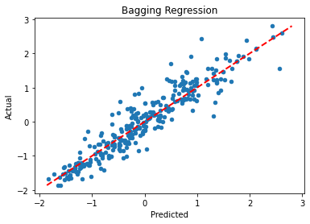

```python
fig, ax = subplots()

ax.scatter(y_predictbr, y_test,s=20)
ax.plot([y_test.min(),y_test.max()],[y_test.min(),y_test.max()],'k--',lw=2,color='red')
plt.title('Bagging Regression')

ax.set_xlabel('Predicted')
ax.set_ylabel("Actual")
plt.show()
```

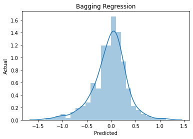

```python
fig, ax = subplots()


sns.distplot(y_predictbr - y_test)
plt.title('Bagging Regression')

ax.set_xlabel('Predicted')
ax.set_ylabel("Actual")
plt.show()
```

##### Observations

- plotting distplot & scatter plot, verifing the model is best fit for this dataset.

#### AdaBossting Regressor

```python
abr=AdaBoostRegressor()

abr.fit(X_train, y_train)

trainingScore=abr.score(X_train,y_train)
testingScore=abr.score(X_test,y_test)
y_predictabr = abr.predict(X_test)


RMSE=np.sqrt(mean_squared_error(y_test,y_predictabr))
MSE = mean_squared_error(y_test, y_predictbr)
MAE = mean_absolute_error(y_test, y_predictbr)
R2Score = r2_score(y_test, y_predictabr)
abr_CV=cross_val_score(abr, X_test, y_test, cv=kfold,scoring='neg_mean_squared_error').ravel()


MLA=abr.__class__.__name__

abr_model=pd.DataFrame([[MLA, trainingScore,testingScore,RMSE,MSE,MAE,R2Score, abr_CV.mean(),abr_CV.std(),abr_CV.min(),abr_CV.max()]],
                          columns=['Model','Training Score','Testing Score','RMSE','MSE','MAE','R2Score','CV_Mean','CV_std','CV_min','CV_max'])

abr_model
```

|  | Model | Training Score | Testing Score | RMSE | MSE | MAE | R2Score | CV_Mean | CV_std | CV_min | CV_max |
| --- | --- | --- | --- | --- | --- | --- | --- | --- | --- | --- | --- |
| 0 | AdaBoostRegressor | 0.807859 | 0.750614 | 0.51022 | 0.117987 | 0.248246 | 0.750614 | -0.239987 | 0.059422 | -0.361087 | -0.156627 |

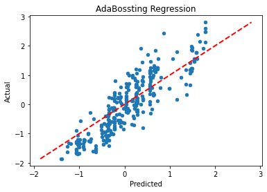

```python
fig, ax = subplots()

ax.scatter(y_predictabr, y_test,s=20)
ax.plot([y_test.min(),y_test.max()],[y_test.min(),y_test.max()],'k--',lw=2,color='red')
plt.title('AdaBossting Regression')

ax.set_xlabel('Predicted')
ax.set_ylabel("Actual")
plt.show()
```

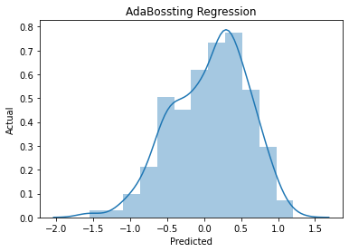

```python
fig, ax = subplots()


sns.distplot(y_predictabr - y_test)
plt.title('AdaBossting Regression')

ax.set_xlabel('Predicted')
ax.set_ylabel("Actual")
plt.show()
```

##### Observations

- plotting distplot & scatter plot, verifing the model is best fit for this dataset.

#### GradientBoosting Regressor

```python
gbr=GradientBoostingRegressor()

gbr.fit(X_train, y_train)

trainingScore=gbr.score(X_train,y_train)
testingScore=gbr.score(X_test,y_test)
y_predictgbr = gbr.predict(X_test)


RMSE=np.sqrt(mean_squared_error(y_test,y_predictgbr))
MSE = mean_squared_error(y_test, y_predictgbr)
MAE = mean_absolute_error(y_test, y_predictgbr)
R2Score = r2_score(y_test, y_predictgbr)
gbr_CV=cross_val_score(abr, X_test, y_test, cv=kfold,scoring='neg_mean_squared_error').ravel()


MLA=gbr.__class__.__name__

gbr_model=pd.DataFrame([[MLA, trainingScore,testingScore,RMSE,MSE,MAE,R2Score, gbr_CV.mean(),gbr_CV.std(),gbr_CV.min(),gbr_CV.max()]],
                          columns=['Model','Training Score','Testing Score','RMSE','MSE','MAE','R2Score','CV_Mean','CV_std','CV_min','CV_max'])

gbr_model
```

|  | Model | Training Score | Testing Score | RMSE | MSE | MAE | R2Score | CV_Mean | CV_std | CV_min | CV_max |
| --- | --- | --- | --- | --- | --- | --- | --- | --- | --- | --- | --- |
| 0 | GradientBoostingRegressor | 0.935208 | 0.877817 | 0.35713 | 0.127542 | 0.26773 | 0.877817 | -0.2503 | 0.067212 | -0.402269 | -0.177272 |

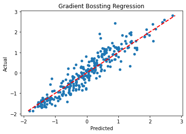

```python
fig, ax = subplots()

ax.scatter(y_predictgbr, y_test,s=20)
ax.plot([y_test.min(),y_test.max()],[y_test.min(),y_test.max()],'k--',lw=2,color='red')
plt.title('Gradient Bossting Regression')

ax.set_xlabel('Predicted')
ax.set_ylabel("Actual")
plt.show()
```

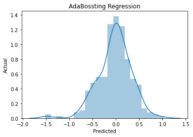

```python
fig, ax = subplots()


sns.distplot(y_predictgbr - y_test)
plt.title('AdaBossting Regression')

ax.set_xlabel('Predicted')
ax.set_ylabel("Actual")

plt.show()
```

##### Observations

- plotting distplot & scatter plot, verifing the model is best fit for this dataset.

```python
# Comparing above all the models

MLModels= pd.concat([linear_model, Poly2Model,Poly3Model,Ridge_model,Lasso_model,dtree_model,rfr_model,br_model,abr_model,gbr_model])
MLModels
```

|  | Model | Training Score | Testing Score | RMSE | MSE | MAE | R2Score | CV_Mean | CV_std | CV_min | CV_max |
| --- | --- | --- | --- | --- | --- | --- | --- | --- | --- | --- | --- |
| 0 | LinearRegression | 0.548984 | 0.574067 | 0.666794 | 0.444615 | 0.545648 | 0.574067 | -0.452963 | 0.106043 | -0.685468 | -0.312445 |
| 0 | PolyNomialDegree2 | 0.610062 | 0.623311 | 0.627065 | 0.393211 | 0.510559 | 0.623311 | -0.412956 | 0.000000 | -0.412956 | -0.412956 |
| 0 | PolyNomialDegree3 | 0.618527 | 0.633315 | 0.618683 | 0.382768 | 0.502633 | 0.633315 | -0.427975 | 0.000000 | -0.427975 | -0.427975 |
| 0 | Ridge | 0.548984 | 0.574020 | 0.666831 | 0.444664 | 0.545700 | 0.574020 | -0.452929 | 0.106177 | -0.686078 | -0.312110 |
| 0 | Lasso | 0.169588 | 0.147109 | 0.943557 | 0.890299 | 0.785277 | 0.147109 | -0.887014 | 0.272762 | -1.395530 | -0.570083 |
| 0 | DecisionTreeRegressor | 0.993459 | 0.843171 | 0.404608 | 0.163708 | 0.278783 | 0.843171 | -0.301554 | 0.063994 | -0.427153 | -0.174923 |
| 0 | RandomForestRegressor | 0.975605 | 0.877422 | 0.357707 | 0.127954 | 0.257744 | 0.877422 | -0.306362 | 0.060104 | -0.411505 | -0.177672 |
| 0 | BaggingRegressor | 0.976107 | 0.886970 | 0.343493 | 0.117987 | 0.248246 | 0.886970 | -0.194693 | 0.065410 | -0.333179 | -0.104479 |
| 0 | AdaBoostRegressor | 0.807859 | 0.750614 | 0.510220 | 0.117987 | 0.248246 | 0.750614 | -0.239987 | 0.059422 | -0.361087 | -0.156627 |
| 0 | GradientBoostingRegressor | 0.935208 | 0.877817 | 0.357130 | 0.127542 | 0.267730 | 0.877817 | -0.250300 | 0.067212 | -0.402269 | -0.177272 |

```python
MLModels[(MLModels['RMSE']==MLModels['RMSE'].min()) & (MLModels['R2Score']==MLModels['R2Score'].max())]
```

|  | Model | Training Score | Testing Score | RMSE | MSE | MAE | R2Score | CV_Mean | CV_std | CV_min | CV_max |
| --- | --- | --- | --- | --- | --- | --- | --- | --- | --- | --- | --- |
| 0 | BaggingRegressor | 0.976107 | 0.88697 | 0.343493 | 0.117987 | 0.248246 | 0.88697 | -0.194693 | 0.06541 | -0.333179 | -0.104479 |

##### Observations

- Compared all the model and min RMSE and max R2score, find out the best model.
- get the best model and do the hypertune.

#### GridSearch to tune the hyper parameter --> Bagging Regressor

```python
from sklearn.model_selection import GridSearchCV
```

```python
bag=BaggingRegressor()
bag.get_params()
```

```
{'base_estimator': None,
 'bootstrap': True,
 'bootstrap_features': False,
 'max_features': 1.0,
 'max_samples': 1.0,
 'n_estimators': 10,
 'n_jobs': None,
 'oob_score': False,
 'random_state': None,
 'verbose': 0,
 'warm_start': False}
```

```python
parameters={'max_samples':[0.5,1.0],'max_features':[1,2,4],'bootstrap':[True, False],'bootstrap_features':[True,False],
             'n_estimators':[50,100,200,500]}

BagGridS=GridSearchCV(estimator=bag,param_grid=parameters, cv=kfold, n_jobs=-1, return_train_score=True)
BagGridS.fit(X_train, y_train.values.ravel())
```

```
GridSearchCV(cv=KFold(n_splits=10, random_state=7, shuffle=False),
       error_score='raise-deprecating',
       estimator=BaggingRegressor(base_estimator=None, bootstrap=True,
         bootstrap_features=False, max_features=1.0, max_samples=1.0,
         n_estimators=10, n_jobs=None, oob_score=False, random_state=None,
         verbose=0, warm_start=False),
       fit_params=None, iid='warn', n_jobs=-1,
       param_grid={'max_samples': [0.5, 1.0], 'max_features': [1, 2, 4], 'bootstrap': [True, False], 'bootstrap_features': [True, False], 'n_estimators': [50, 100, 200, 500]},
       pre_dispatch='2*n_jobs', refit=True, return_train_score=True,
       scoring=None, verbose=0)
```

```python
BagGridS.best_params_
```

```
{'bootstrap': True,
 'bootstrap_features': False,
 'max_features': 4,
 'max_samples': 1.0,
 'n_estimators': 200}
```

```python
print("Best Score:",BagGridS.best_score_)
```

```
Best Score: 0.8845464531320829
```

```python
bagTree=BagGridS.best_estimator_
bagTree
```

```
BaggingRegressor(base_estimator=None, bootstrap=True,
         bootstrap_features=False, max_features=4, max_samples=1.0,
         n_estimators=200, n_jobs=None, oob_score=False, random_state=None,
         verbose=0, warm_start=False)
```

```python
bagTree.fit(X_train, y_train)


trainingScore=bagTree.score(X_train,y_train)
testingScore=bagTree.score(X_test,y_test)
y_predictbagTree = bagTree.predict(X_test)


RMSE=np.sqrt(mean_squared_error(y_test,y_predictbagTree))
MSE = mean_squared_error(y_test, y_predictbagTree)
MAE = mean_absolute_error(y_test, y_predictbagTree)
R2Score = r2_score(y_test, y_predictbagTree)
bagTree_CV=cross_val_score(bagTree, X_test, y_test, cv=kfold,scoring='neg_mean_squared_error').ravel()


#MLA=rfTree.__class__.__name__

bagTree_model=pd.DataFrame([["Bagging-GridSearch", trainingScore,testingScore,RMSE,MSE,MAE,R2Score, bagTree_CV.mean(),bagTree_CV.std(),bagTree_CV.min(),bagTree_CV.max()]],
                          columns=['Model','Training Score','Testing Score','RMSE','MSE','MAE','R2Score','CV_Mean','CV_std','CV_min','CV_max'])

bagTree_model
```

|  | Model | Training Score | Testing Score | RMSE | MSE | MAE | R2Score | CV_Mean | CV_std | CV_min | CV_max |
| --- | --- | --- | --- | --- | --- | --- | --- | --- | --- | --- | --- |
| 0 | Bagging-GridSearch | 0.980832 | 0.895378 | 0.33047 | 0.10921 | 0.239871 | 0.895378 | -0.178562 | 0.058834 | -0.330076 | -0.128435 |

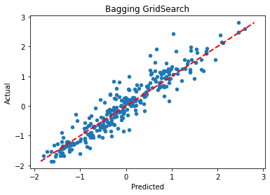

```python
fig, ax = subplots()

ax.scatter(y_predictbagTree, y_test,s=20)
ax.plot([y_test.min(),y_test.max()],[y_test.min(),y_test.max()],'k--',lw=2,color='red')
plt.title('Bagging GridSearch')

ax.set_xlabel('Predicted')
ax.set_ylabel("Actual")
plt.show()
```

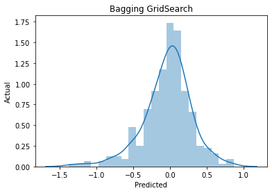

```python
fig, ax = subplots()


sns.distplot(y_predictbagTree - y_test)
plt.title('Bagging GridSearch')

ax.set_xlabel('Predicted')
ax.set_ylabel("Actual")

plt.show()
```

##### Observations

- To use Bagging Regressor model to tune the hyper parameter and to find out the level of metrics.

#### GridSearch to tune the hyper parameter --> GradientBoosting Regressor

```python
from time import time
```

```python
gbrcv=GradientBoostingRegressor()
gbrcv.get_params()
```

```
{'alpha': 0.9,
 'criterion': 'friedman_mse',
 'init': None,
 'learning_rate': 0.1,
 'loss': 'ls',
 'max_depth': 3,
 'max_features': None,
 'max_leaf_nodes': None,
 'min_impurity_decrease': 0.0,
 'min_impurity_split': None,
 'min_samples_leaf': 1,
 'min_samples_split': 2,
 'min_weight_fraction_leaf': 0.0,
 'n_estimators': 100,
 'n_iter_no_change': None,
 'presort': 'auto',
 'random_state': None,
 'subsample': 1.0,
 'tol': 0.0001,
 'validation_fraction': 0.1,
 'verbose': 0,
 'warm_start': False}
```

```python
start_time=time()
parameters=[{"loss":["ls","lad"],
    "min_samples_leaf": np.linspace(0.1, 0.5),
    "max_depth": [3,5,8],
    "max_features":["log2","sqrt"],
    "subsample":[0.9]}]

gbrcv_grid=GridSearchCV(estimator=gbrcv, param_grid=parameters, cv=kfold, n_jobs=1, return_train_score=True)
print(gbrcv_grid.fit(X_train, y_train))
print('total time: %s' % (time() - start_time))
```

```
GridSearchCV(cv=KFold(n_splits=10, random_state=7, shuffle=False),
       error_score='raise-deprecating',
       estimator=GradientBoostingRegressor(alpha=0.9, criterion='friedman_mse', init=None,
             learning_rate=0.1, loss='ls', max_depth=3, max_features=None,
             max_leaf_nodes=None, min_impurity_decrease=0.0,
             min_impurity_split=None, min_samples_leaf=1,
             min_sampl...=None, subsample=1.0, tol=0.0001,
             validation_fraction=0.1, verbose=0, warm_start=False),
       fit_params=None, iid='warn', n_jobs=1,
       param_grid=[{'loss': ['ls', 'lad'], 'min_samples_leaf': array([0.1    , 0.10816, 0.11633, 0.12449, 0.13265, 0.14082, 0.14898,
       0.15714, 0.16531, 0.17347, 0.18163, 0.1898 , 0.19796, 0.20612,
       0.21429, 0.22245, 0.23061, 0.23878, 0.24694, 0.2551 , 0.26327,
       0.27143, 0.27959, 0.28776, ...84,
       0.5    ]), 'max_depth': [3, 5, 8], 'max_features': ['log2', 'sqrt'], 'subsample': [0.9]}],
       pre_dispatch='2*n_jobs', refit=True, return_train_score=True,
       scoring=None, verbose=0)
total time: 384.0869779586792
```

```python
gbrcv_grid.best_params_
```

```
{'loss': 'ls',
 'max_depth': 5,
 'max_features': 'log2',
 'min_samples_leaf': 0.1,
 'subsample': 0.9}
```

```python
gbrcv_grid.best_score_
```

```
0.8670059777212665
```

```python
gbrcvTree=gbrcv_grid.best_estimator_
gbrcvTree
```

```
GradientBoostingRegressor(alpha=0.9, criterion='friedman_mse', init=None,
             learning_rate=0.1, loss='ls', max_depth=5,
             max_features='log2', max_leaf_nodes=None,
             min_impurity_decrease=0.0, min_impurity_split=None,
             min_samples_leaf=0.1, min_samples_split=2,
             min_weight_fraction_leaf=0.0, n_estimators=100,
             n_iter_no_change=None, presort='auto', random_state=None,
             subsample=0.9, tol=0.0001, validation_fraction=0.1, verbose=0,
             warm_start=False)
```

```python
gbrcvTree.fit(X_train, y_train)


trainingScore=gbrcvTree.score(X_train,y_train)
testingScore=gbrcvTree.score(X_test,y_test)
y_predictgbrTree = gbrcvTree.predict(X_test)


RMSE=np.sqrt(mean_squared_error(y_test,y_predictgbrTree))
MSE = mean_squared_error(y_test, y_predictgbrTree)
MAE = mean_absolute_error(y_test, y_predictgbrTree)
R2Score = r2_score(y_test, y_predictgbrTree)
gbrCVTree_CV=cross_val_score(gbrcvTree, X_test, y_test, cv=kfold,scoring='neg_mean_squared_error').ravel()


#MLA=rfTree.__class__.__name__

gbrcvTree_model=pd.DataFrame([["GradientBoostingRegressor-GridSearch", trainingScore,testingScore,RMSE,MSE,MAE,R2Score, gbrCVTree_CV.mean(),gbrCVTree_CV.std(),gbrCVTree_CV.min(),gbrCVTree_CV.max()]],
                          columns=['Model','Training Score','Testing Score','RMSE','MSE','MAE','R2Score','CV_Mean','CV_std','CV_min','CV_max'])

gbrcvTree_model
```

|  | Model | Training Score | Testing Score | RMSE | MSE | MAE | R2Score | CV_Mean | CV_std | CV_min | CV_max |
| --- | --- | --- | --- | --- | --- | --- | --- | --- | --- | --- | --- |
| 0 | GradientBoostingRegressor-GridSearch | 0.893783 | 0.86669 | 0.373038 | 0.139157 | 0.294419 | 0.86669 | -0.168434 | 0.035347 | -0.244167 | -0.125778 |

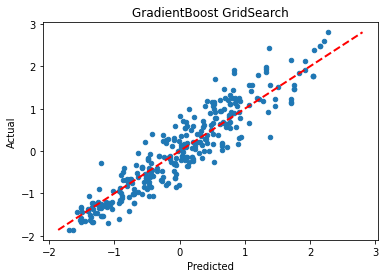

```python
fig, ax = subplots()

ax.scatter(y_predictgbrTree, y_test,s=20)
ax.plot([y_test.min(),y_test.max()],[y_test.min(),y_test.max()],'k--',lw=2,color='red')
plt.title('GradientBoost GridSearch')

ax.set_xlabel('Predicted')
ax.set_ylabel("Actual")
plt.show()
```

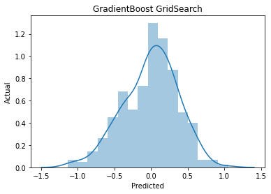

```python
fig, ax = subplots()


sns.distplot(y_predictgbrTree - y_test)
plt.title('GradientBoost GridSearch')

ax.set_xlabel('Predicted')
ax.set_ylabel("Actual")

plt.show()
```

##### Observations

- To use Gardient Boosting Regressormodel to tune the hyper parameter and to find out the level of metrics.

```python
# Comparing a model in dataframe
hyperTuningGCV=pd.concat([bagTree_model, gbrcvTree_model])
hyperTuningGCV
```

|  | Model | Training Score | Testing Score | RMSE | MSE | MAE | R2Score | CV_Mean | CV_std | CV_min | CV_max |
| --- | --- | --- | --- | --- | --- | --- | --- | --- | --- | --- | --- |
| 0 | Bagging-GridSearch | 0.980832 | 0.895378 | 0.330470 | 0.109210 | 0.239871 | 0.895378 | -0.178562 | 0.058834 | -0.330076 | -0.128435 |
| 0 | GradientBoostingRegressor-GridSearch | 0.893783 | 0.866690 | 0.373038 | 0.139157 | 0.294419 | 0.866690 | -0.168434 | 0.035347 | -0.244167 | -0.125778 |

```python
# get the best model from above 2 algorithm
hyperTuningGCV[(hyperTuningGCV['RMSE']==hyperTuningGCV['RMSE'].min()) & (hyperTuningGCV['R2Score']==hyperTuningGCV['R2Score'].max())]
```

|  | Model | Training Score | Testing Score | RMSE | MSE | MAE | R2Score | CV_Mean | CV_std | CV_min | CV_max |
| --- | --- | --- | --- | --- | --- | --- | --- | --- | --- | --- | --- |
| 0 | Bagging-GridSearch | 0.980832 | 0.895378 | 0.33047 | 0.10921 | 0.239871 | 0.895378 | -0.178562 | 0.058834 | -0.330076 | -0.128435 |

#### Conclusion

- Tuning a models and comparing 2 models, chossing best fit model for this dataset.
- The Bagging is a best model 89%